# Analiza danych - raport

Borowiak Maria, Foriasz Olga, Klaman Zuzanna, Martynów Mateusz, Warzecha Tomasz

2025-01-24

# 1 Znajdź najpopularniejsze rodzaje wycieczek, porównaj koszta i zyski, czy są opłacalne?

Porównanie kosztów i zysków wycieczek

| ID Wycieczki | Nazwa Wycieczki | Dochód z Wycieczki | Koszt Organizacji Wycieczki | Łączny Zysk z Wycieczki |
| --- | --- | --- | --- | --- |
| 4 | Lot motoparalotnią nad Wrocławiem | 31238 | 16500 | 14738 |
| 2 | Symulacja inwazji smoków | 34125 | 20000 | 14125 |
| 5 | Podwodna ekspedycja w Odrze | 36660 | 24000 | 12660 |
| 3 | Skok na bungee z Mostu Grunwaldzkiego | 21405 | 11000 | 10405 |
| 6 | Tyrolka z Mostu Zwierzynieckiego | 30708 | 21000 | 9708 |
| 1 | Spacer po dachach Wrocławia | 25120 | 17200 | 7920 |

**Wnioski dotyczące najpopularniejszych wycieczek i ich opłacalności**

1. **Najbardziej dochodowa wycieczka:**
   - Podwodna ekspedycja w Odrze wygenerowała najwyższy dochód w wysokości **36,660 zł**, jednak jej całkowity zysk wyniósł **12,660 zł**, co czyni ją mniej opłacalną w porównaniu do innych wycieczek.
2. **Najbardziej opłacalna wycieczka:**
   - **Lot motoparalotnią nad Wrocławiem** okazał się najbardziej opłacalny, przynosząc zysk w wysokości **14,738 zł** przy stosunkowo niskim koszcie organizacji wynoszącym **16,500 zł**.
3. **Najmniej opłacalna wycieczka:**
   - Spacer po dachach Wrocławia, mimo że dochód z tej wycieczki wyniósł **25,120 zł**, przyniósł najmniejszy zysk – tylko **7,920 zł**, co może wskazywać na wysokie koszty organizacyjne w stosunku do osiągniętych przychodów.
4. **Ogólne obserwacje:**
   - Wszystkie wycieczki przyniosły zyski, jednak różnią się one znacznie pod względem *opłacalności*.
   - *Wycieczki o niższych kosztach organizacyjnych wydają się bardziej dochodowe w przeliczeniu na jednostkę kosztu*, co sugeruje potencjalne obszary optymalizacji kosztów dla wycieczek o wyższych wydatkach.
   - Analiza pokazuje, że *wycieczki o wysokim dochodzie nie zawsze generują największe zyski*. Optymalizacja kosztów organizacji może zwiększyć opłacalność oferty.

# 2 Sporządź wykres liczby obsłużonych klientów w każdym miesiącu działalności firmy, czy firma rośnie, czy podupada?

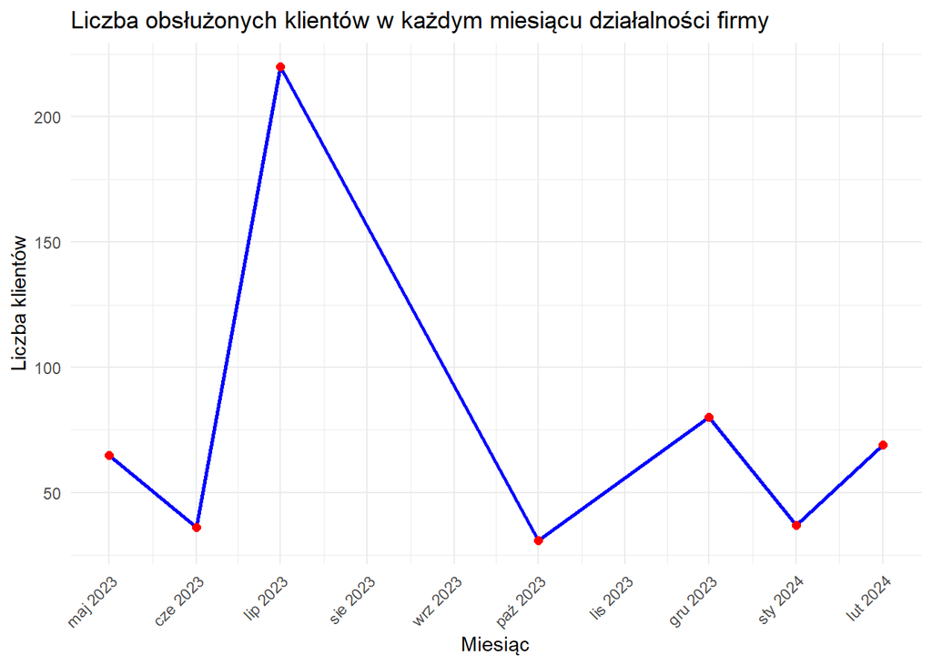

# 3 Sprawdź, po których wycieczkach klienci wracają na kolejne, a po których mają dość i więcej ich nie widzicie. Czy są takie, które być może powinny zniknąć z oferty?

Powroty klientów po wycieczkach

| ID Wycieczki | Nazwa Wycieczki | Liczba Powrotów | Liczba Braku Powrotu | Liczba Uczestników | Procent Powrotów | Procent Braku Powrotu |
| --- | --- | --- | --- | --- | --- | --- |
| 2 | Symulacja inwazji smoków | 47 | 23 | 70 | 67.14 | 32.86 |
| 4 | Lot motoparalotnią nad Wrocławiem | 59 | 39 | 98 | 60.20 | 39.80 |
| 5 | Podwodna ekspedycja w Odrze | 11 | 13 | 24 | 45.83 | 54.17 |
| 6 | Tyrolka z Mostu Zwierzynieckiego | 87 | 122 | 209 | 41.63 | 58.37 |
| 3 | Skok na bungee z Mostu Grunwaldzkiego | 26 | 47 | 73 | 35.62 | 64.38 |
| 1 | Spacer po dachach Wrocławia | 18 | 46 | 64 | 28.13 | 71.88 |

# 4 Jak cena wycieczki wpływa na częstotliwość jej wyboru przez klientów?

Wpływ ceny wycieczki na liczbę uczestników

| Cena Wycieczki | Liczba Uczestników | Procent Uczestników |
| --- | --- | --- |
| 150 | 209 | 38.85 |
| 325 | 98 | 18.22 |
| 300 | 73 | 13.57 |
| 500 | 70 | 13.01 |
| 400 | 64 | 11.90 |
| 1560 | 24 | 4.46 |

# 5 Którzy pracownicy obsługujący wycieczki generują największą ilość rezerwacji wycieczek przez klientów?

Pracownicy generujący największą ilość rezerwacji

| ID Pracownika | Imię | Nazwisko | Liczba Wycieczek | Liczba Uczestników |
| --- | --- | --- | --- | --- |
| 2 | Maks | Kuban | 10 | 297 |
| 1 | Błażej | Bakun | 5 | 168 |
| 5 | Nataniel | Wiak | 2 | 73 |

**Wnioski dotyczące pracowników obsługujących wycieczki**

1. **Pracownik obsługujący największą liczbę wycieczek:**
   - **Maks Kuban** obsłużył najwięcej wycieczek (*10*) oraz przyciągnął największą liczbę uczestników (*297*). Jego wyniki wskazują na efektywną organizację i wysoką popularność obsługiwanych wycieczek.
2. **Pozostali pracownicy:**
   - **Błażej Bakun** zorganizował *5* wycieczek, obsługując łącznie *168* uczestników, co również świadczy o dobrych wynikach w swojej roli.
   - **Nataniel Wiak** obsłużył najmniejszą liczbę wycieczek (*2*) i miał najmniejszą liczbę uczestników (*73*), co może wskazywać na potrzebę zwiększenia jego zaangażowania w organizację wycieczek.
3. **Ogólne obserwacje:**
   - Maksymalna liczba obsłużonych uczestników przez jednego pracownika (297 przez Maksa Kubana) pokazuje, że odpowiednie zaangażowanie i organizacja mogą znacząco zwiększyć liczbę uczestników przypadających na pracownika.
   - Istnieje duża różnica między liczbą wycieczek obsługiwanych przez Maksa Kubana a pozostałych pracowników, co sugeruje, że warto przeanalizować, czy wszyscy pracownicy mają równe możliwości i obciążenie obowiązkami.
   - Warto nagrodzić Maksa Kubana za jego wyniki i przeanalizować jego metody pracy, aby wdrożyć je jako standard w całym zespole.
   - Pracownicy, tacy jak Nataniel Wiak, mogą potrzebować dodatkowego wsparcia lub szkolenia, aby zwiększyć liczbę obsługiwanych wycieczek.

# 6 W jakim przedziale wiekowym są klienci najczęściej decydujący się na skorzystanie z usług firmy?

Przedziały wiekowe klientów korzystających z usług firmy

| Przedział Wiekowy | Liczba Klientów |
| --- | --- |
| 41-50 | 52 |
| 31-40 | 51 |
| 71-80 | 48 |
| 21-30 | 44 |
| 61-70 | 44 |
| 51-60 | 39 |
| 0-20 | 12 |

**Wnioski dotyczące przedziałów wiekowych klientów korzystających z usług firmy**

1. **Najczęściej korzystający przedział wiekowy:**
   - Najwięcej klientów firmy pochodzi z przedziału wiekowego **41-50 lat** (52 osoby). To grupa wiekowa, która najchętniej korzysta z usług firmy, co może sugerować, że oferta jest szczególnie atrakcyjna dla osób w tym wieku.
2. **Inne popularne grupy wiekowe:**
   - **31-40 lat** to kolejny znaczący przedział wiekowy, obejmujący **51 klientów**, co pokazuje, że młodsi dorośli również stanowią dużą część klienteli firmy.
   - **71-80 lat** (48 klientów) wskazuje na zainteresowanie ofertą firmy również przez seniorów, co jest istotnym sygnałem o różnorodności klientów.
3. **Mniej popularne przedziały wiekowe:**
   - Przedziały wiekowe **21-30 lat** i **61-70 lat** (po 44 klientów w każdym) wskazują na umiarkowane zainteresowanie ofertą firmy w tych grupach.
   - **51-60 lat** (39 klientów) oraz **0-20 lat** (12 klientów) to najmniej liczne grupy wiekowe, co może sugerować, że oferta firmy jest mniej dopasowana do potrzeb młodzieży oraz starszych pracujących.
4. **Ogólne obserwacje:**
   - Oferta firmy wydaje się być najlepiej dopasowana do grup wiekowych **41-50 lat** oraz **31-40 lat**, które razem stanowią znaczną część klientów.
   - Grupa wiekowa **71-80 lat** wskazuje na zainteresowanie usługami firmy wśród seniorów, co może być okazją do rozwinięcia oferty skierowanej do tej grupy.
   - Warto zastanowić się nad możliwością zwiększenia atrakcyjności oferty dla osób młodszych (0-20 lat) oraz starszych pracujących (51-60 lat), aby poszerzyć bazę klientów.

# 7 Czy posiadana przez klienta zniżka sprawia, że wybiera on dane wycieczki częściej niż osoby bez zniżek?

Wpływ posiadania zniżki na częstotliwość wyboru wycieczek

| Typ Klienta | Liczba Transakcji | Liczba Klientów | Średnia Transakcji na Klienta |
| --- | --- | --- | --- |
| ze zniżką | 123 | 66 | 1.86 |
| brak zniżki | 415 | 224 | 1.85 |

**Wnioski dotyczące wpływu zniżek na częstotliwość wyboru wycieczek przez klientów**

1. **Średnia liczba transakcji na klienta:**
   - Klienci ze zniżką dokonali średnio **1.86 transakcji**, co jest bardzo zbliżone do średniej liczby transakcji klientów bez zniżek (**1.85 transakcji**). Wynik ten sugeruje, że posiadanie zniżki nie wpływa znacząco na liczbę wycieczek wybieranych przez klientów.
2. **Łączna liczba transakcji i klientów:**
   - Klienci bez zniżek wygenerowali znacząco więcej transakcji (**415**) w porównaniu do klientów posiadających zniżki (**123**). Różnica ta wynika głównie z większej liczby klientów bez zniżek (**224** wobec **66** ze zniżkami).
3. **Ogólne obserwacje:**
   - Mimo że klienci bez zniżek generują większą liczbę transakcji, średnia liczba transakcji na klienta jest niemal identyczna dla obu grup. Może to sugerować, że posiadanie zniżki nie jest kluczowym czynnikiem wpływającym na decyzję o częstszym korzystaniu z wycieczek.
   - Zniżki mogą być skuteczne w przyciąganiu nowych klientów, jednak analiza wskazuje, że ich wpływ na lojalność lub częstotliwość rezerwacji jest minimalny.
   - Posiadanie zniżki nie wpływa znacząco na częstotliwość rezerwacji wycieczek, jednak może pomóc w przyciągnięciu nowych klientów. Dalsza optymalizacja oferty może przynieść lepsze rezultaty.

# 8 Która z wycieczek cieszyła się największym zainteresowaniem wśród klientów, jeśli chodzi o wielokrotne uczestnictwo?

Wycieczki o największej liczbie ponownego uczestnictwa

| ID Wycieczki | Nazwa Wycieczki | Liczba Ponownego Uczestnictwa |
| --- | --- | --- |
| 6 | Tyrolka z Mostu Zwierzynieckiego | 42 |
| 4 | Lot motoparalotnią nad Wrocławiem | 12 |
| 3 | Skok na bungee z Mostu Grunwaldzkiego | 4 |
| 2 | Symulacja inwazji smoków | 4 |
| 1 | Spacer po dachach Wrocławia | 4 |
| 5 | Podwodna ekspedycja w Odrze | 0 |

**Wnioski dotyczące wycieczek cieszących się największym zainteresowaniem wśród klientów w kontekście wielokrotnego uczestnictwa**

1. **Najpopularniejsza wycieczka pod względem wielokrotnego uczestnictwa:**
   - **Tyrolka z Mostu Zwierzynieckiego** osiągnęła największą liczbę ponownych uczestnictw – **42**. To zdecydowanie najpopularniejsza wycieczka w kontekście powracających klientów, co sugeruje, że jest szczególnie atrakcyjna i dobrze oceniana.
2. **Inne wycieczki z powracającymi klientami:**
   - **Lot motoparalotnią nad Wrocławiem** zajmuje drugie miejsce z liczbą ponownych uczestnictw wynoszącą **12**, co wskazuje na jej popularność, choć na mniejszą skalę niż w przypadku Tyrolki.
   - Wycieczki takie jak **Skok na bungee z Mostu Grunwaldzkiego**, **Symulacja inwazji smoków** oraz **Spacer po dachach Wrocławia** przyciągnęły po **4 ponownych uczestników** każda. Oznacza to, że są atrakcyjne, ale ich potencjał w generowaniu lojalności jest ograniczony.
3. **Wycieczka bez powracających klientów:**
   - **Podwodna ekspedycja w Odrze** nie zanotowała żadnego ponownego uczestnictwa, co może wskazywać na brak wystarczającej atrakcyjności lub konieczność poprawy wrażeń z tej wycieczki.
4. **Ogólne obserwacje:**
   - Wycieczki o charakterze dynamicznym, takie jak Tyrolka z Mostu Zwierzynieckiego, wydają się bardziej angażujące i zachęcają klientów do powrotów.
   - Wycieczki, które nie przyciągają ponownych uczestników, mogą wymagać analizy i modyfikacji, aby lepiej odpowiadać na potrzeby klientów.
   - Należy skupić się na dalszej promocji i utrzymaniu wysokiego standardu wycieczki **Tyrolka z Mostu Zwierzynieckiego**, która zdecydowanie wyróżnia się pod względem ponownych uczestnictw.
   - Wycieczki takie jak **Podwodna ekspedycja w Odrze** wymagają analizy opinii klientów, aby zidentyfikować powody braku powrotów i wdrożyć ewentualne zmiany.
   - Firma powinna inwestować w rozwój i promocję wycieczek, które przyciągają powracających klientów, oraz analizować te, które nie generują lojalności.